# GAN

Shan-Hung Wu & DataLab  
Fall 2018

In this lab, we are going to introduce an unsupervised learning model: [Generative adversarial network(GAN)](https://papers.nips.cc/paper/5423-generative-adversarial-nets.pdf)

The architecture of GAN look like following.

[figure not shown]

GAN has two main components in the model, generator and discriminator. Discriminator tries to discriminate real data from generated data and generator tries to generate real-like data to fool discriminator. The training process alternates between optimizing discriminator and optimizing generator. As long as discriminator was smart enough, it can lead generator to go toward the manifold of real datas.

[figure not shown]

## DCGAN

DCGAN is short for Deep Convolutional Generative Adversarial Networks. It is a paper that doing well on image task, its architecture increase training stability and quality of generated sample. In this lab, we modified the code of [DCGAN](https://arxiv.org/pdf/1511.06434.pdf). We will demo the training of DCGAN on MNIST dataset.

[figure not shown]

Some suggestions in DCGAN(referenced from paper):

- Replace any pooling layers with strided convolutions (discriminator) and fractional-strided convolutions (generator).
  - Each convolutional layer halved the feature maps resolution. (Not hard requirement.)
- Use batchnorm in both the generator and the discriminator.
  - The batchnorm here is the simplest one just normalizing the feature activations.
  - Don't use batchnorm in the last few layers in generator. Since it may make it difficult for generator to fit the variance of real data. For example, if the mean of data is not zero, and we use batchnorm and Tanh in the last layer of G, then it will never match the true data distribution.
- Use ReLU activation in generator for all layers except for the output, which uses Tanh or Sigmoid.
  - Tanh or Sigmoid depends on the range of real data.
- Use LeakyReLU activation in the discriminator for all layers.
  - LeakyReLu is recommened by AllConvNet approach for faster training.

In the following code, we

1. design the model architecture following suggestion proposed in dcgan.
2. initialize DCGAN and train on the MNIST dataset.

```python
import warnings
warnings.filterwarnings("ignore")
```

```python
%matplotlib inline
import sys
sys.path.append('GAN')

import os
os.environ['CUDA_VISIBLE_DEVICES'] = "0"
import matplotlib.pyplot as plt
import numpy as np
import tensorflow as tf
import time
import math
import numpy as np
```

```python
from tensorflow.keras.datasets import mnist
# load data
(x_train, _),(x_test, _) = mnist.load_data()
x_train, x_test = x_train / 255.0, x_test / 255.0
```

```python
# utility function
import scipy
import moviepy.editor as mpy
def visualize_imgs(imgs, shape, save_path=None):
    (row, col) = shape[0], shape[1]
    height, width = imgs[0].shape[:2]
    total_img = np.zeros((height*row, width*col))
    for n, img in enumerate(imgs):
        j = int(n/col)
        i = n%col
        total_img[j*height:(j+1)*height,i*width:(i+1)*width] = img
    if save_path is not None:
        scipy.misc.imsave(save_path, img)
    return total_img

def make_gif(images, fname, duration=2, true_image=False):
    def make_frame(t):
        try:
            x = images[int(len(images)/duration*t)]
        except:
            x = images[-1]

        if true_image:
            return x.astype(np.uint8)
        else:
            return ((x+1)/2*255).astype(np.uint8)

    clip = mpy.VideoClip(make_frame, duration=duration)
    clip.write_gif(fname, fps = len(images) / duration)
def iter_data(*data, **kwargs):
    size = kwargs.get('batch_size', 128)
    try:
        n = len(data[0])
    except:
        n = data[0].shape[0]
    batches = int(n / size)
    if n % size != 0:
        batches += 1
    for b in range(batches):
        start = b * size
        end = (b + 1) * size
        if end > n:
            end = n
        if len(data) == 1:
            yield data[0][start:end]
        else:
            yield tuple([d[start:end] for d in data])
```

```python
class DCGAN(object):
    def __init__(self, image_size, image_channel, z_dim=128, learning_rate=1e-4):
        self.image_size = image_size
        self.image_channel = image_channel
        self.z_dim = z_dim
        self.learning_rate = learning_rate
        self.build_model()

    def build_model(self):
        if self.image_channel==1:
            self.image_real = tf.placeholder(tf.float32,
                                             [None, self.image_size, self.image_size])
        else:
            self.image_real = tf.placeholder(tf.float32,
                                             [None, self.image_size,
                                              self.image_size, self.image_channel])

        # create generator
        self.image_fake = self.generator()

        # create discriminator and get its prediction for real/fake image
        self.pred_real, self.logit_real = self.discriminator(self.image_real)
        self.pred_fake, self.logit_fake = self.discriminator(self.image_fake)

        # loss of discriminator
        self.d_loss_real = tf.reduce_mean(tf.nn.sigmoid_cross_entropy_with_logits(
                                          logits=self.logit_real,
                                          labels=tf.ones_like(self.logit_real)))
        self.d_loss_fake = tf.reduce_mean(tf.nn.sigmoid_cross_entropy_with_logits(
                                          logits=self.logit_fake,
                                          labels=tf.zeros_like(self.logit_fake)))
        self.d_loss = self.d_loss_real + self.d_loss_fake

        # loss of generator
        self.g_loss = tf.reduce_mean(tf.nn.sigmoid_cross_entropy_with_logits(
                                          logits=self.logit_fake,
                                          labels=tf.ones_like(self.logit_fake)))

        # create optimize operation for discriminator
        self.d_vars = tf.get_collection(tf.GraphKeys.TRAINABLE_VARIABLES, 'discriminator')
        self.d_update_op = tf.train.AdamOptimizer(self.learning_rate).minimize(self.d_loss,
                                                                            var_list=self.d_vars)

        # create optimize operation for generator
        self.g_vars = tf.get_collection(tf.GraphKeys.TRAINABLE_VARIABLES, 'generator')
        self.g_update_op = tf.train.AdamOptimizer(self.learning_rate).minimize(self.g_loss,
                                                                             var_list=self.g_vars)

    def discriminator(self, image):
        lrelu = tf.nn.leaky_relu
        conv2d = tf.layers.conv2d
        bn = tf.layers.batch_normalization
        linear = tf.layers.dense
        with tf.variable_scope("discriminator", reuse=tf.AUTO_REUSE):
            if self.image_channel==1:
                image = tf.reshape(image, [-1, self.image_size, self.image_size, 1])
            hidden = self.z
            hidden = image
            hidden = lrelu(conv2d(hidden, 32, kernel_size=5, strides=2, padding='same'))
            hidden = lrelu(bn(conv2d(hidden, 128, kernel_size=5, strides=2, padding='same'),
                              training=True))
            hidden = tf.layers.flatten(hidden)
            hidden = lrelu(bn(linear(hidden, 1024), training=True))
            hidden = linear(hidden, 1)
            return tf.nn.sigmoid(hidden), hidden

    def generator(self, y=None):
        relu = tf.nn.relu
        deconv2d = tf.layers.conv2d_transpose
        bn = tf.layers.batch_normalization
        linear = tf.layers.dense
        with tf.variable_scope("generator"):
            self.z = tf.placeholder(tf.float32, [None, self.z_dim], name='z')
            hidden = self.z
            hidden = relu(bn(linear(hidden, 1024), training=True))
            hidden = relu(bn(linear(hidden, (self.image_size//4)*(self.image_size//4)*128),
                             training=True))
            hidden = tf.reshape(hidden, [-1, self.image_size//4, self.image_size//4, 128])
            hidden = relu(bn(deconv2d(hidden, 32, kernel_size=5, strides=2, padding='same'),
                             training=True))
            hidden = tf.nn.sigmoid(deconv2d(hidden, self.image_channel, kernel_size=5,
                                            strides=2, padding='same'))
            if self.image_channel==1:
                hidden = tf.reshape(hidden, [-1, self.image_size, self.image_size])
            return hidden

    def train(self, sess, x_train, num_epoch=100, batch_size=100, num_sample=100,
              show_samples=True, sample_path='./samples', n_critic=2, log=False):
        # sample some random noise, these noise is used to monitor generated image
        sample_z = np.random.uniform(-1, 1, size=(num_sample , self.z_dim))
        sample_imgs = []

        counter = 1
        start_time = time.time()
        d_loss_epoch = []
        g_loss_epoch = []
        for epoch in range(num_epoch):
            shuffle_idx = np.random.permutation(len(x_train))
            x_train = x_train[shuffle_idx]
            d_losses = []
            g_losses = []
            for batch_images in iter_data(x_train, batch_size=batch_size):
                batch_z = np.random.uniform(-1, 1,
                                            [batch_size, self.z_dim]).astype(np.float32)
                if counter % (n_critic+1) != 0:
                    # Update D network
                    feed_dict={
                        self.image_real: batch_images,
                        self.z: batch_z,
                    }
                    d_loss, _ = sess.run([self.d_loss, self.d_update_op],
                                         feed_dict=feed_dict)
                    d_losses.append(d_loss)
                else:
                    # Update G network
                    g_loss, _ = sess.run([self.g_loss, self.g_update_op],
                                         feed_dict={self.z: batch_z})
                    g_losses.append(g_loss)
                counter += 1
            if log:
                print("Epoch: [{}] time: {:.2f}, d_loss: {:.4f}, g_loss: {:.4f}".format(
                      epoch, time.time()-start_time, np.mean(d_losses), np.mean(g_losses)))
            d_loss_epoch.append(np.mean(d_losses))
            g_loss_epoch.append(np.mean(g_losses))

            # save generated samples
            samples = sess.run(self.image_fake, feed_dict={self.z: sample_z})
            if not os.path.exists(sample_path):
                os.makedirs(sample_path)
            img = visualize_imgs(samples, shape=(10,20),
                                 save_path=sample_path+'/epoch-{}.jpg'.format(epoch))
            sample_imgs.append(img)

            if (epoch+1) % 10 == 0:
                if show_samples:
                    plt.imshow(img, cmap = 'gray')
                    plt.axis('off')
                    plt.title('epoch {}'.format(epoch+1))
                    plt.show()
        return sample_imgs, d_loss_epoch, g_loss_epoch

    def save_model(self, sess, checkpoint_dir='./checkpoints', model_name='model', step=None):
        if not os.path.exists(checkpoint_dir):
            os.makedirs(checkpoint_dir)
        saver = tf.train.Saver()
        if step is not None:
            saver.save(sess, os.path.join(checkpoint_dir, model_name), global_step=step)
        else:
            saver.save(sess, os.path.join(checkpoint_dir, model_name))

    def load_model(self, sess, checkpoint_dir='./checkpoints', model_name='model', step=None):
        saver = tf.train.Saver()
        if step is not None:
            saver.save(sess, os.path.join(checkpoint_dir, model_name+'-{}'.format(step)))
        else:
            saver.save(sess, os.path.join(checkpoint_dir, model_name))
```

```python
tf.reset_default_graph()
tf.set_random_seed(123)
np.random.seed(123)
dcgan = DCGAN(image_size=28, image_channel=1)

sess = tf.Session()
sess.run(tf.global_variables_initializer())
```

Let's plot the generated images right after the initialization. It's good to check if there are any unexpacted artifacts in it. For case of DCGAN, we should see checkboard effect in our generated samples if we use fully convolutional layers. As mentioned in this [blog post](http://distill.pub/2016/deconv-checkerboard/), this will introduce some checkboard effect. If the training is succeed, then this effect can be largely reduced. The blog post used upsampling to replace strided deconvolution in generator. This can cancell off the checkboard effect but have more blury result.

In the following cell, we also plot the original MNIST dataset.

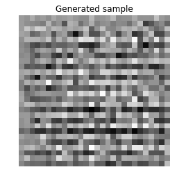

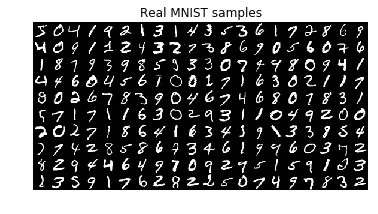

```python
sample_z = np.random.uniform(-1, 1, size=(200 , 128))
samples = sess.run(dcgan.image_fake, feed_dict = {dcgan.z: sample_z})
plt.imshow(samples[0].reshape(28,28), cmap='gray')
plt.axis('off')
plt.title('Generated sample')
plt.show()

samples = x_train[:200]
img = visualize_imgs(samples, shape=(10,20))
plt.imshow(img, cmap='gray')
plt.axis('off')
plt.title('Real MNIST samples')
plt.show()
```

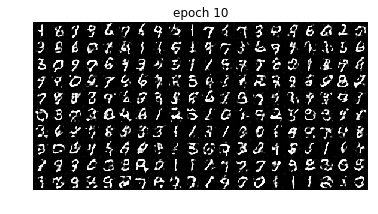

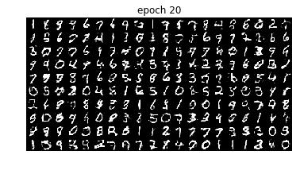

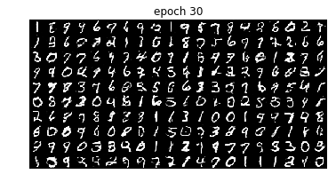

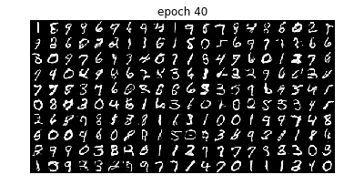

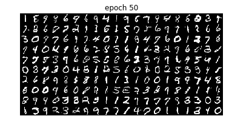

```python
# train with d_step:g_etsp = 5:1
sample_imgs, d_loss_epoch, g_loss_epoch = dcgan.train(sess, x_train,
                                                      num_sample=200,
                                                      num_epoch=50, n_critic=5)
```

```python
imgs = np.array(sample_imgs)
make_gif(imgs*255., 'GAN/dcgan1.gif', true_image=True, duration=2)

from IPython.display import Image
Image(url='GAN/dcgan1.gif')
```

```
[MoviePy] Building file GAN/dcgan1.gif with imageio
```

[figure not shown]

We plot the training loss of discriminator and generator. We can see that we can't tell the model is converged or not from the training loss. Both curves oscillate at certain levels and it's independent with the quality of the generated images. So in practice, we plot the generated samples to monitor the training process. And due to this inconvenience, there are some works proposed in 2017 tried to solved it.

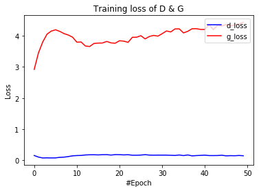

```python
plt.plot(range(len(d_loss_epoch)), d_loss_epoch, color = 'blue', label = 'd_loss')
plt.plot(range(len(g_loss_epoch)), g_loss_epoch, color = 'red', label = 'g_loss')
plt.legend(loc="upper right")
plt.xlabel('#Epoch')
plt.ylabel('Loss')
plt.title('Training loss of D & G')
plt.show()
```

# Wasserstein GAN

There are some theoretical deficiencies in vanilla GAN. [Wasserstein GAN (WGAN)](https://arxiv.org/pdf/1701.07875.pdf) was proposed to solve these problems. Apart from the original paper, [this](https://www.cph-ai-lab.com/wasserstein-gan-wgan) and [this](https://www.alexirpan.com/2017/02/22/wasserstein-gan.html) may help you understand the motivation of WGAN. We'll skip the theory in this tutorial and jump directly to the implementation. From the engineering perspective, the following are modification compared with origin GAN.

- Don't apply sigmoid function to the last layer for the critic
- Don't apply logarithmic function to the generator loss and critic loss
- Training critic multiple iterations per generator iteration
- Using RMSProp as the optimizer, instead of momentum related optimizer like Adam. [Here](http://ruder.io/optimizing-gradient-descent/index.html#rmsprop) is a blog overview of gradient descent optimization algorithm.
- Applying weight clipping in the critic network

Details of the algorithm are shown below.

[figure not shown]

```python
#Inherit from DCGAN class
class WGAN(DCGAN):
    def build_model(self):
        if self.image_channel==1:
            self.image_real = tf.placeholder(tf.float32,
                                             [None, self.image_size, self.image_size])
        else:
            self.image_real = tf.placeholder(tf.float32,
                                             [None, self.image_size,
                                              self.image_size, self.image_channel])

        # create generator
        self.image_fake = self.generator()

        # create discriminator and get its prediction for real/fake image
        self.pred_real, self.logit_real = self.discriminator(self.image_real)
        self.pred_fake, self.logit_fake = self.discriminator(self.image_fake)

        # loss of discriminator
        self.d_loss_real = tf.reduce_mean(self.logit_real)
        self.d_loss_fake = tf.reduce_mean(self.logit_fake)
        self.d_loss = self.d_loss_fake - self.d_loss_real

        # loss of generator
        self.g_loss = -tf.reduce_mean(self.logit_fake)

        # create optimize operation for discriminator
        self.d_vars = tf.get_collection(tf.GraphKeys.TRAINABLE_VARIABLES, 'discriminator')
        self.d_update_op = tf.train.RMSPropOptimizer(self.learning_rate).minimize(self.d_loss,
                                                                        var_list=self.d_vars)

        # create optimize operation for generator
        self.g_vars = tf.get_collection(tf.GraphKeys.TRAINABLE_VARIABLES, 'generator')
        self.g_update_op = tf.train.RMSPropOptimizer(self.learning_rate).minimize(self.g_loss,
                                                                        var_list=self.g_vars)

        # create weight cliping operation
        self.weight_clip_ops = []
        for var in self.d_vars:
            self.weight_clip_ops.append(var.assign(tf.clip_by_value(var, -0.01, 0.01)))

    def train(self, sess, x_train, num_epoch=100, batch_size=100,
              num_sample=100, show_samples=True, n_critic=2,
              sample_path='./samples', log=False):

        # sample some random noise, these noise is used to monitor generated image
        sample_z = np.random.uniform(-1, 1, size=(num_sample , self.z_dim))
        sample_imgs = []

        counter = 1
        start_time = time.time()
        d_loss_epoch = []
        g_loss_epoch = []
        for epoch in range(num_epoch):
            shuffle_idx = np.random.permutation(len(x_train))
            x_train = x_train[shuffle_idx]
            d_losses = []
            g_losses = []
            for batch_images in iter_data(x_train, batch_size=batch_size):
                batch_z = np.random.uniform(-1, 1,
                                            [batch_size, self.z_dim]).astype(np.float32)
                if counter % (n_critic+1) != 0:
                    # Update D network
                    feed_dict={
                        self.image_real: batch_images,
                        self.z: batch_z,
                    }
                    d_loss, _ = sess.run([self.d_loss, self.d_update_op],
                                         feed_dict=feed_dict)
                    d_losses.append(d_loss)
                    sess.run(self.weight_clip_ops)
                else:
                    # Update G network
                    g_loss, _ = sess.run([self.g_loss, self.g_update_op],
                                         feed_dict={self.z: batch_z})
                    g_losses.append(g_loss)
                counter += 1
            if log:
                print("Epoch: [{}] time: {:.2f}, d_loss: {:.4f}, g_loss: {:.4f}".format(
                      epoch, time.time()-start_time, np.mean(d_losses), np.mean(g_losses)))
            d_loss_epoch.append(np.mean(d_losses))
            g_loss_epoch.append(np.mean(g_losses))

            # save generated samples
            samples = sess.run(self.image_fake, feed_dict={self.z: sample_z})
            if not os.path.exists(sample_path):
                os.makedirs(sample_path)
            img = visualize_imgs(samples, shape=(10,20),
                                 save_path=sample_path+'/epoch-{}.jpg'.format(epoch))
            sample_imgs.append(img)

            if (epoch+1) % 10 == 0:
                self.save_model(sess, step=counter)
                if show_samples:
                    plt.imshow(img, cmap = 'gray')
                    plt.axis('off')
                    plt.title('epoch {}'.format(epoch+1))
                    plt.show()
        return sample_imgs, d_loss_epoch, g_loss_epoch
```

Then we train the WGAN and visualize the training as before.

```python
tf.reset_default_graph()
tf.set_random_seed(123)
np.random.seed(123)
wgan = WGAN(image_size=28, image_channel=1, learning_rate=5e-5)

sess = tf.Session()
sess.run(tf.global_variables_initializer())
```

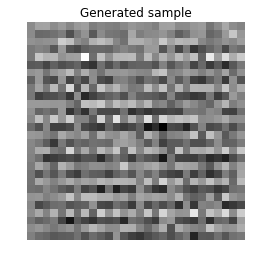

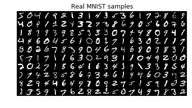

```python
sample_z = np.random.uniform(-1, 1, size=(200 , wgan.z_dim))
samples = sess.run(wgan.image_fake, feed_dict = {wgan.z: sample_z})

plt.imshow(samples[0].reshape(28,28), cmap='gray')
plt.axis('off')
plt.title('Generated sample')
plt.show()

samples = x_train[:200]
img = visualize_imgs(samples, shape=(10,20))
plt.imshow(img, cmap='gray')
plt.axis('off')
plt.title('Real MNIST samples')
plt.show()
```

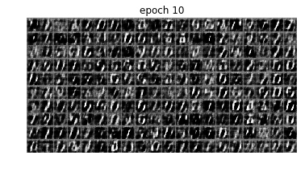

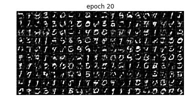

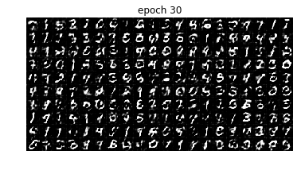

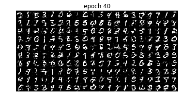

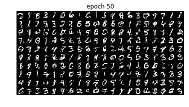

```python
# Start training
sample_imgs, d_loss_epoch, g_loss_epoch = wgan.train(sess, x_train, num_sample=200, num_epoch=50, n_critic=5)
```

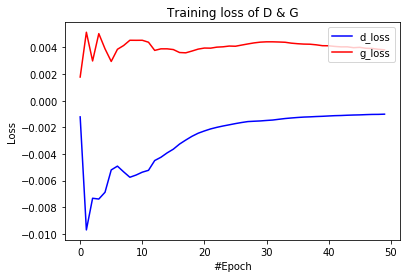

```python
plt.plot(range(len(d_loss_epoch)), d_loss_epoch, color = 'blue', label = 'd_loss')
plt.plot(range(len(g_loss_epoch)), g_loss_epoch, color = 'red', label = 'g_loss')
plt.legend(loc="upper right")
plt.xlabel('#Epoch')
plt.ylabel('Loss')
plt.title('Training loss of D & G')
plt.show()
```

```python
imgs = np.array(sample_imgs)
make_gif(imgs*255., 'GAN/wgan.gif', true_image=True, duration=2)

from IPython.display import Image
Image(url='GAN/wgan.gif')
```

```
[MoviePy] Building file GAN/wgan.gif with imageio
```

[figure not shown]

# Improved WGAN

Although Wasserstein GAN (WGAN) made progress toward stable training of GANs, still fail to converge in some settings. In this lab, you are required to implement [Improved Wasserstein GANs](https://arxiv.org/pdf/1704.00028.pdf), which is a milestone for GANs research.

We will show the training result of Improved WGAN below, which indicates that, compared to WGAN, Improved WGAN has a much better performance. It generates recognizable digits much faster during the training process.

Details of the algorithm are shown below.

[figure not shown]

```python
from IPython.display import Image
Image(url='GAN/iwgan.gif')
```

[figure not shown]

# Assignment

1. Implement the [Improved WGAN](https://arxiv.org/pdf/1704.00028.pdf) and train it on the MNIST dataset. Then draw a gif of generated samples (10 x 20) to demonstrate the training process and show the best-generated samples you get.
2. Come up or survey some applications of GAN. Write in or paste link in notebook.
3. Write a brief report about what you learn.

## Notification

- Submit the notebook named Lab14_2_{strudent_id}.ipynb to demonstrate your codes and report on iLMS.
- Give a brief report to on what you have done.
- The deadline will be 2018/12/6 15:30